# Regressão linear e correlação

## Regressão linear

## Regressão linear

Regressão é o método usado quando tanto a resposta quanto a variável explicativa são **contínuas**:

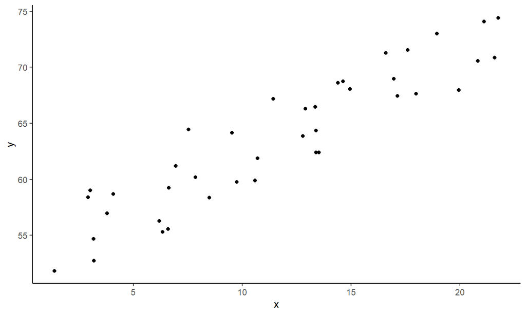

## Regressão linear simples

A forma mais simples que existe de regressão é:

\[ y_i=a+bx_i \]

Ou seja, apenas dois parâmetros e uma variável explicativa. Isso é uma **regressão linear simples**:

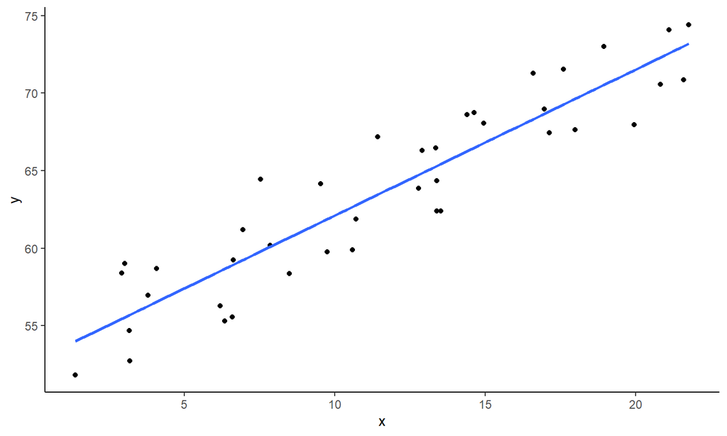

## Regressão linear múltipla

Porém, pode haver mais de uma variável explicando \(y\):

\[ y_i=\beta_0+\beta_1x_1+\beta_2x_2 \]

Ou seja, eu posso estimar o valor de cada \(y\) a partir do valor de duas outras variáveis ou mais:

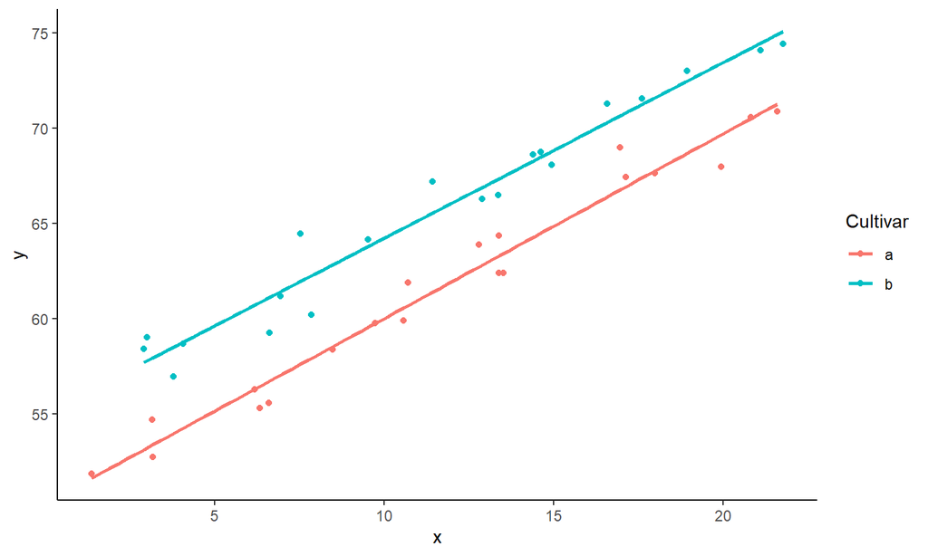

## Regressão polinomial

É comum descrevermos a relação entre variáveis por uma reta, porém, também podemos usar outra relação que não seja linear. Nesse contexto, temos a regressão polinomial que não é nada mais que um tipo de regressão linear múltipla:

\[ y_i=a+b_1x_i+b_2x_i^2 \]

\(*\) **Cuidado com a terminologia!** **Modelo linear** é diferente de uma **relação linear**. Uma relação linear é uma simples reta descrevendo duas variáveis. Já um modelo linear se trata dos coeficientes ligados linearmente, ou seja, uma regressão polinomial também é um modelo linear.

## Regressão polinomial

Regressão linear é um polinomio de primeiro grau. Se adicionarmos novamente nossa mesma variável explicativa, porém, elevada a um determinado grau, teremos uma regressão polinomial:

- Polinômio de primeiro grau: \(resposta \sim explicativa^1\)
- Polinômio de segundo grau: \(resposta \sim explicativa^1+explicativa^2\)
- Polinômio de terceiro grau: \(resposta \sim explicativa^1+explicativa^2+explicativa^3\)

\(*\) **Atenção!** Descrever a relação entre as variáveis é diferente de explicar sua relação de causa e efeito.

## Regressão polinomial

Cada grau adiciona uma curvatura a mais no nosso gráfico, logo, fica evidente que em algum momento, a regressão polinomial poderá passar em quase todos os pontos.

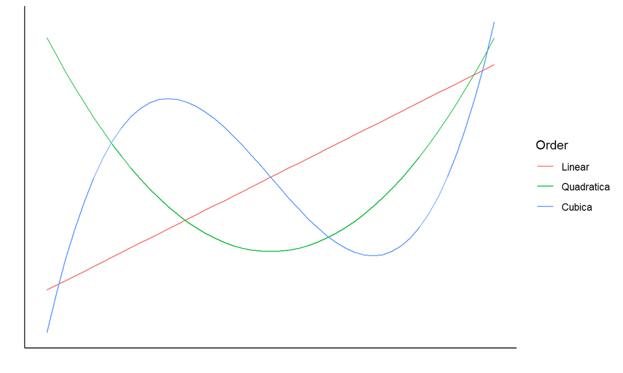

**A ideia é achar até qual grau devemos ir.**

## Pressupostos

Os coeficientes em um modelo linear são estimados pelos métodos dos mínimos quadrados. Logo, a regressão linear também exige dos erros:

- **Ser independentes**: os erros não devem apresentar correlação entre si.
- **Ter variância homogênea (homocedásticos)**: todos os erros variam de forma igual.
- **Ser normais**: erros possuem distribuição normal com média igual a zero.

## Como avaliar a regressão?

Existem duas formas:

- **Teste F** compara a contribuição de modelos simples em relação aos mais complexos por meio da função **anova()**.
  - É um teste feito em sequência, do modelo mais simples ao mais complexo. A ideia é identificar se a de informação a mais que um modelo mais complexo explica é siginificantemente melhor do que um modelo mais simples. **Se não for, então para que um modelo complicado?**
- **Teste t** compara se cada coeficiente de cada variável do modelo é significativamente diferente de zero por meio da função **summary()**.
  - A ideia aqui é checar se um determinado coeficiente, na presença dos outros, é necessários. **Se não for, então para que ter ele no modelo?**

## Como avaliar a regressão?

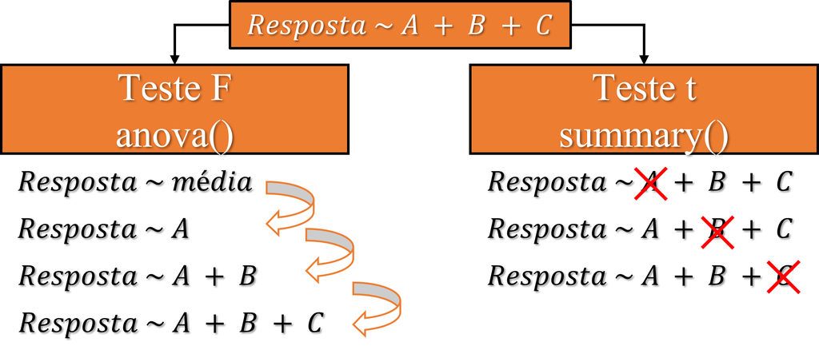

## Coeficiente de determinação (\(R^2\))

Quão melhor minha regressão explica a variação observada nos dados? O \(R^2\) responde:

\[ R^2=1-\frac{Soma\;de\;quadrados\;residual}{Soma\;de\;quadrados\;total} \]

O \(R^2\) varia de 0 a 1, pois uma regressão pode explicar até no máximo 100% da variação observada na resposta.

## Coeficiente de determinação (\(R^2\))

Visualmente fica mais fácil:

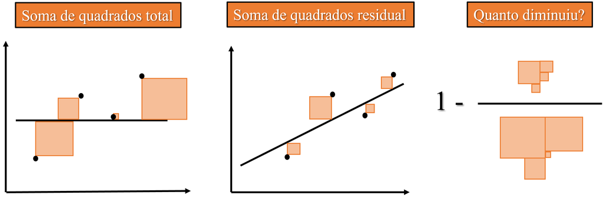

## Coeficiente de determinação ajustado (\(R^2_{adj}\))

O coeficiente de determinação ajustado é o \(R^2\) “corrigido” para o número de variáveis que o modelo usou:

\[ R^2=1-\frac{Soma\;de\;quadrados\;residual/GL_{regressão}}{Soma\;de\;quadrados\;total/GL_{total}} \]

Por que corrigir? Porque seu \(R^2\). sempre será maior quanto mais variáveis você usar para descrever a sua resposta!

## Exemplos no R - regressão

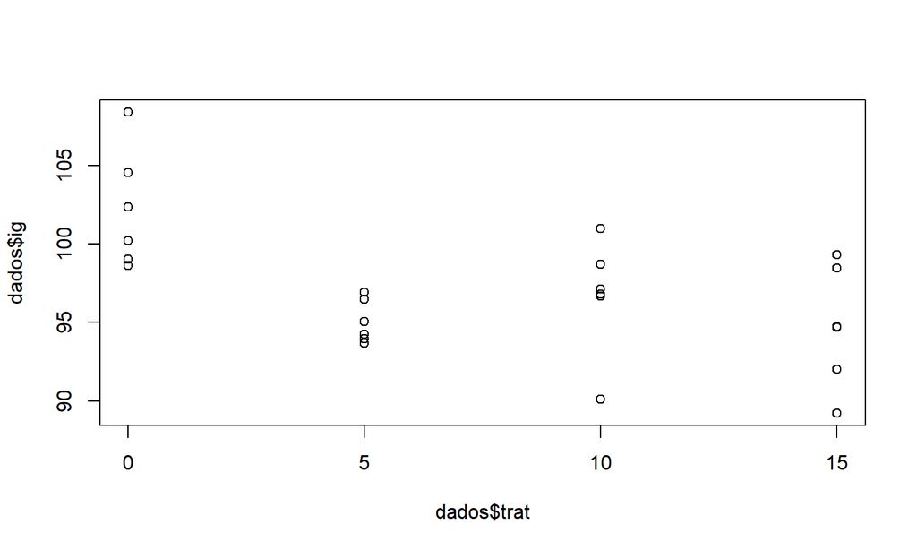

```r
library(ExpDes.pt) # carregar pacotes com dados de exemplo ("ex1")
dados <- ex1 # armazenar dados de exemplo em "dados"
plot(dados$trat, dados$ig) # gráfico de dispersão
```

## Exemplos no R - regressão

Ajustando um modelo de regressão polinomial de maior ordem.

```r
modelo.cubico <- lm(ig~trat+I(trat^2)+I(trat^3), data=dados) # modelo cúbico
```

## Exemplos no R - checando os pressupostos

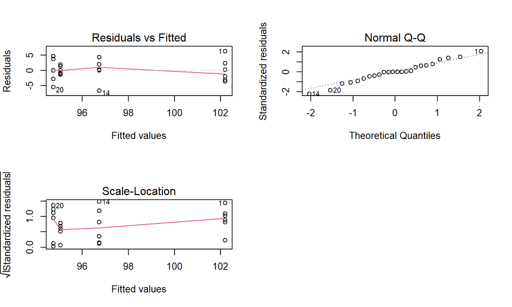

```r
par(mfrow=c(2,2)) # dividir painel gráfico
plot(modelo.cubico) # plotar gráfico
```

## Exemplos no R - teste t

```r
summary(modelo.cubico) # teste t
```

```
##
## Call:
## lm(formula = ig ~ trat + I(trat^2) + I(trat^3), data = dados)
##
## Residuals:
##     Min      1Q  Median      3Q     Max
## -6.6233 -1.5408  0.0042  1.9004  6.2317
##
## Coefficients:
##               Estimate Std. Error t value Pr(>|t|)
## (Intercept) 102.198333   1.352994  75.535  < 2e-16 ***
## trat         -3.144500   1.038275  -3.029  0.00663 **
## I(trat^2)     0.426700   0.183529   2.325  0.03071 *
## I(trat^3)    -0.016680   0.008068  -2.068  0.05187 .
## ---
## Signif. codes:  0 '***' 0.001 '**' 0.01 '*' 0.05 '.' 0.1 ' ' 1
##
## Residual standard error: 3.314 on 20 degrees of freedom
## Multiple R-squared:  0.4945, Adjusted R-squared:  0.4187
## F-statistic: 6.521 on 3 and 20 DF,  p-value: 0.002962
```

## Exemplos no R - teste F

Vamos testar a contribuição sequêncial dos modelos pela **anova()**:

```r
modelo.nulo <- lm(ig~1, data=dados) # modelo mais simples
modelo.linear <- lm(ig~trat, data=dados) # modelo linear
modelo.quadratico <- lm(ig~trat+I(trat^2), data=dados) # modelo quadrático
anova(modelo.nulo, modelo.linear, modelo.quadratico, modelo.cubico) # comparação dos modelos
```

```
## Analysis of Variance Table
##
## Model 1: ig ~ 1
## Model 2: ig ~ trat
## Model 3: ig ~ trat + I(trat^2)
## Model 4: ig ~ trat + I(trat^2) + I(trat^3)
##   Res.Df    RSS Df Sum of Sq       F   Pr(>F)
## 1     23 434.55
## 2     22 306.25  1   128.299 11.6810 0.002727 **
## 3     21 266.62  1    39.629  3.6081 0.072019 .
## 4     20 219.67  1    46.950  4.2746 0.051872 .
## ---
## Signif. codes:  0 '***' 0.001 '**' 0.01 '*' 0.05 '.' 0.1 ' ' 1
```

\(*\) Repare que após o modelo linear, os modelos não contribuem significativamente, então, ficamos com ele.

## Exemplos no R - teste F

Mesmo resultado:

```r
anova(modelo.cubico) # anova da regressão
```

```
## Analysis of Variance Table
##
## Response: ig
##           Df  Sum Sq Mean Sq F value   Pr(>F)
## trat       1 128.299 128.299 11.6810 0.002727 **
## I(trat^2)  1  39.629  39.629  3.6081 0.072019 .
## I(trat^3)  1  46.950  46.950  4.2746 0.051872 .
## Residuals 20 219.671  10.984
## ---
## Signif. codes:  0 '***' 0.001 '**' 0.01 '*' 0.05 '.' 0.1 ' ' 1
```

## Exemplos no R - teste F

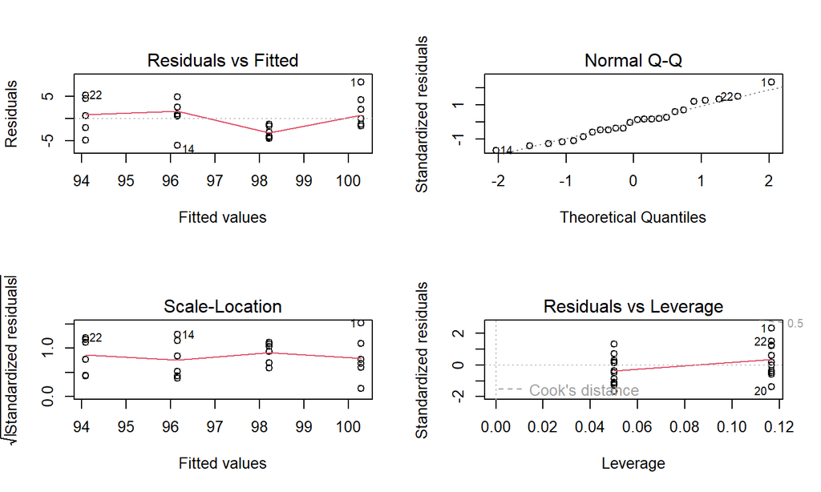

```r
par(mfrow=c(2,2)) # dividir o painel
plot(modelo.linear) # plotar o modelo
```

## Teste da falta de ajuste

Como em experimentos planejados temos **repetições no mesmo nível** a situação fica um pouco diferente. Podemos considerar como níveis de um fator ou como uma variável númerica contínua, ou seja, podemos realizar uma **regressão** quanto uma **anova**.

[figure not shown]

E então? Consideramos como categorias ou como variável numérica contínua?

## Teste da falta de ajuste

Podemos testar a falta de ajuste de um modelo de regressão, comparando ele com o modelo que considera a variável como níveis de um fator.

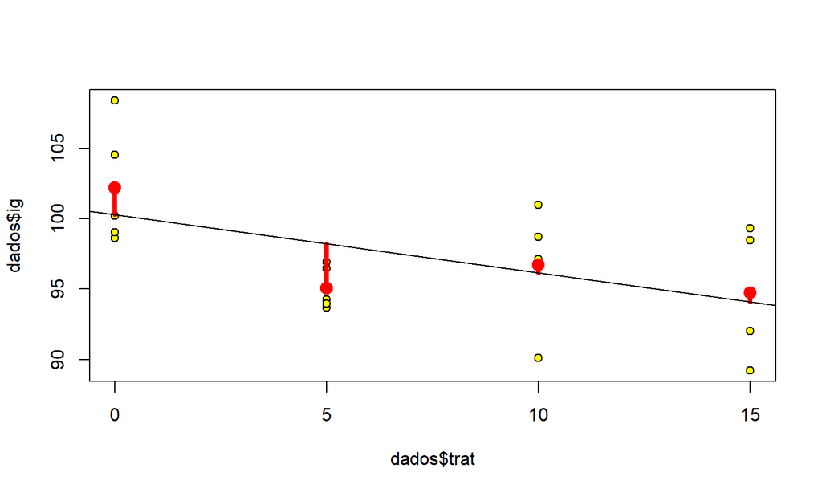

\(*\) A falta de ajuste não é nada mais que a **diferença entre a regressão e as médias de cada nível.**

## Exemplos no R - Teste da falta de ajuste

Podemos testar em sequência, do modelo mais simples até o modelo que não tem diferença em relação ao modelo considerando a variável como níveis de um fator:

```r
modelo.categorias <- lm(ig~as.factor(trat), data=dados) # modelo considerando categoria
anova(modelo.linear, modelo.categorias) # testar falta de ajuste
```

```
## Analysis of Variance Table
##
## Model 1: ig ~ trat
## Model 2: ig ~ as.factor(trat)
##   Res.Df    RSS Df Sum of Sq      F  Pr(>F)
## 1     22 306.25
## 2     20 219.67  2    86.579 3.9413 0.03605 *
## ---
## Signif. codes:  0 '***' 0.001 '**' 0.01 '*' 0.05 '.' 0.1 ' ' 1
```

Repare que a diferença entre os dois modelos foi significativa, isso significa que a **regressão linear não é adequada, pois a falta de ajuste entre os modelos é significativo.**

## Exemplos no R - Teste da falta de ajuste

Então, se regressão linear não é adequada, o que fazer?

```r
anova(modelo.categorias, modelo.quadratico) # comparar os modelos
```

```
## Analysis of Variance Table
##
## Model 1: ig ~ as.factor(trat)
## Model 2: ig ~ trat + I(trat^2)
##   Res.Df    RSS Df Sum of Sq      F  Pr(>F)
## 1     20 219.67
## 2     21 266.62 -1    -46.95 4.2746 0.05187 .
## ---
## Signif. codes:  0 '***' 0.001 '**' 0.01 '*' 0.05 '.' 0.1 ' ' 1
```

## Exemplos no R - Teste da falta de ajuste

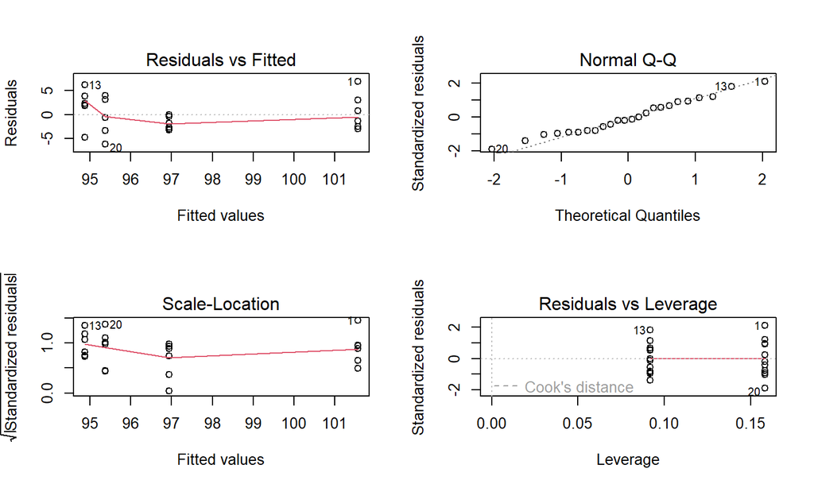

```r
par(mfrow=c(2,2)) # dividir o painel
plot(modelo.quadratico) # plotar o modelo
```

## Exemplos no R - Pacote ExpDes.pt

```r
library(ExpDes.pt) # carregar pacote
dados <- ex1 # armazenar ex1 em "dados"
dic(dados$trat, dados$ig, quali=FALSE) # dic com fator quantitativo
```

```
## ------------------------------------------------------------------------
## Quadro da analise de variancia
## ------------------------------------------------------------------------
##            GL     SQ     QM     Fc     Pr>Fc
## Tratamento  3 214.88 71.626 6.5212 0.0029622
## Residuo    20 219.67 10.984
## Total      23 434.55
## ------------------------------------------------------------------------
## CV = 3.41 %
##
## ------------------------------------------------------------------------
## Teste de normalidade dos residuos ( Shapiro-Wilk )
## Valor-p:  0.91697
## De acordo com o teste de Shapiro-Wilk a 5% de significancia, os residuos podem ser considerados normais.
## ------------------------------------------------------------------------
##
## ------------------------------------------------------------------------
## Teste de homogeneidade de variancia
## valor-p:  0.1863216
## De acordo com o teste de bartlett a 5% de significancia, as variancias podem ser consideradas homogeneas.
## ------------------------------------------------------------------------
##
## Ajuste de modelos polinomiais de regressao
## ------------------------------------------------------------------------
##
## Modelo Linear
## =========================================
##    Estimativa Erro.padrao   tc    valor.p
## -----------------------------------------
## b0  100.2878    1.1320    88.5938    0
## b1  -0.4136     0.1210    -3.4177 0.0027
## -----------------------------------------
##
## R2 do modelo linear
## --------
## 0.597077
## --------
##
## Analise de variancia do modelo linear
## =======================================================
```

[output cut: 44 more lines]

```
## -
## 1
## -
##
## Analise de variancia do modelo cubico
## =======================================================
##                      GL    SQ       QM     Fc   valor.p
## -------------------------------------------------------
## Efeito linear        1  128.2987 128.2987 11.68 0.00273
## Efeito quadratico    1  39.6294  39.6294  3.61  0.07202
## Efeito cubico        1  46.9500  46.9500  4.27  0.05187
## Desvios de Regressao 0     0        0       0      1
## Residuos             20 219.6710 10.9836
## -------------------------------------------------------
## ------------------------------------------------------------------------
```

## Exemplos no R - gerando o gráfico

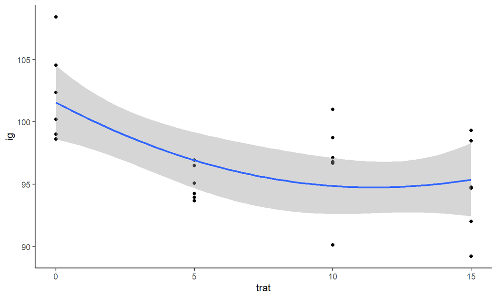

```r
library(ggplot2) # carregando o pacote
ggplot(dados) + # indicando os dados
  aes(x=trat, y=ig) + # distribuindo as variáveis
  geom_point() + # gráfico de dispersão
  geom_smooth(formula=y~poly(x, 2), method="lm") + # adicionando linha de regressão
  theme_classic() # alterando a estética
```

## Ideias principais

- Para usar um modelo mais complexo, ele precisa explicar significativamente que um modelo mais simples.
- O \(R^2\) diz quanto da variação é explicada pelo seu modelo de regressão. Use o \(R^2\) ajustado ao comparar modelos mais complexos.
- Se você tem variáveis que podem ser consideradas tanto como quantitativas quanto como níveis de um fator:
  1. Considere elas como fator e faça a anova conforme o seu delineamento para checar se o efeito do tratamento é significativo.
  2. Considere ela quantitativa e ajuste modelos de diferentes ordens.
  3. Em cada ordem, da menor para maior, compare com o modelo que considera como níveis de um fator por meio da **anova()**. O modelo primeiro modelo que não for significativamente diferente é o seu modelo.

## Correlação

## Associação entre variáveis

Para sabermos se duas variáveis estão relacionadas, podemos medir o grau de associação entre elas. Porém, a forma de medir a associação entre duas variáveis, depende da classe delas:

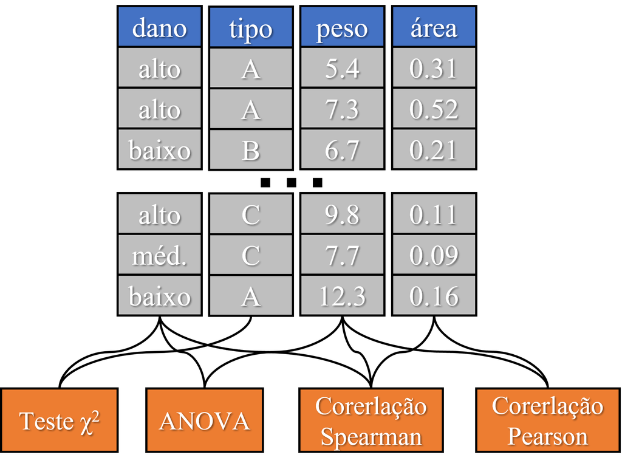

## Correlação de Pearson

A **correlação de pearson (r)** mede a relação **linear** entre duas variáveis, ou seja, **x** e **y** formando uma linha reta. É uma medida de **correlação paramétrica**, pois depende da distribuição dos dados, os quais devem ser **normalmente distribuidos** e pode ser calculada por:

\[ r=\frac{1}{n}\sum(\frac{x_i-\bar{x}}{DP(X)})(\frac{y_i-\bar{y}}{DP(Y)}) \]

A correlação de Pearson não é nada mais que a média (\(\frac{1}{n}\sum\)) da variação conjunta de \(x\) e \(y\) ((\(x_i-\bar{x}\))(\(y_i-\bar{y}))\), dividida pelo desvio padrão (\(DP\)) para anular a diferença de escala entre as variáveis.

## Correlação de Pearson

A medida varia de -1 e 1 e indica:

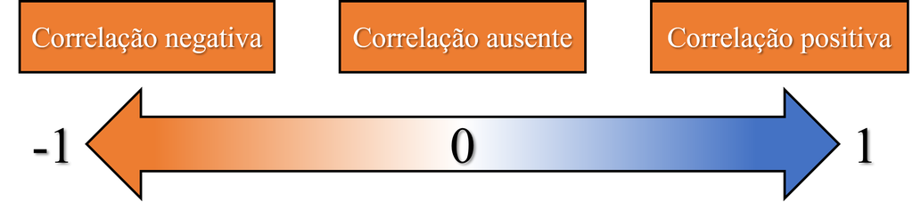

## Correlação de Pearson

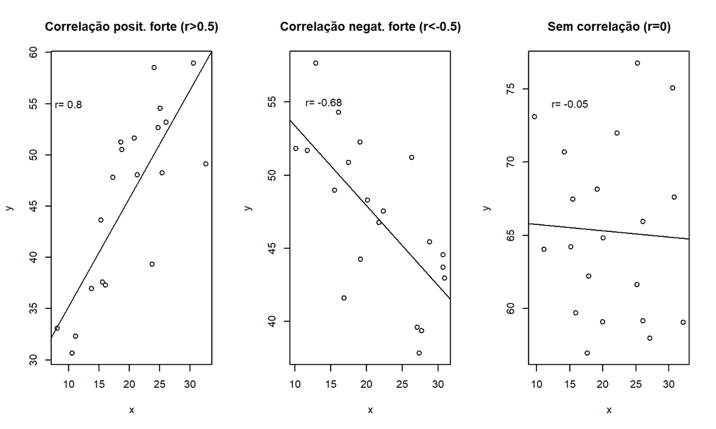

## Correlação de Pearson - problemas

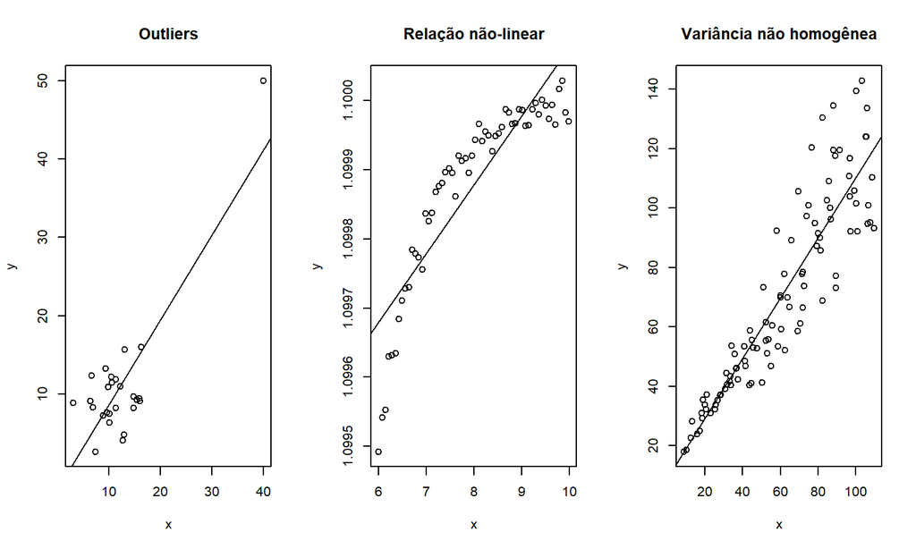

## Correlação de Spearman

Correlação de Spearman é uma **correlação baseada no ranqueamento**:

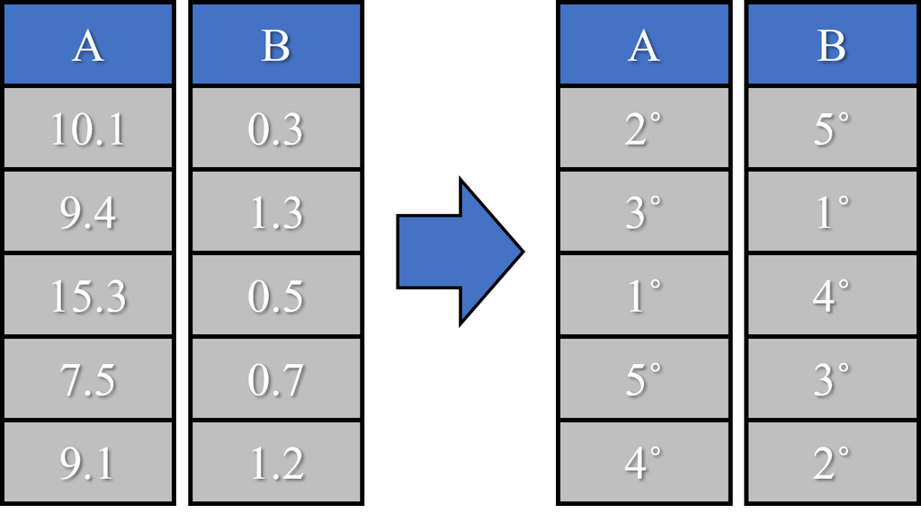

Por esse motivo, é capaz identificar de forma geral a tendência de aumento ou diminuição entre dados e **não apenas a sua relação linear**, como a correlação de pearson.

## Correlação de Spearman

A correlação de Spearman é uma correlação **não-paramétrica** e é indicada para:

- Dado não-normais;
- Que possuem relação não-linear entre variáveis;
- Dados com possíveis outliers;

\(*\) **Atenção**, pelo fato da correlação de Spearman baseada no ranqueamento dos dados, é possível utilizá-la em **dados categóricos ordinais**: nível de infestação de uma doença, classes de qualidade, entre outros.

## Correlação no R

\[ cor(x, y, method,...) \]

- **x** e **y** podem ser tanto um vetor com cada variável, quanto uma matriz ou objeto do tipo data frame.
  - Quando é fornecido uma matriz ou data frame, não é necessário especificar o **y** e o resultado será uma matriz de correlação entre todas as variáveis.
- **method** define qual correlação deverá ser calculada:
  - Pearson: **method=“pearson”**
  - Spearman: **method=“spearman”**

## Exemplos no R - correlação

### \(1^\circ\) Carregando dados e criando gráfico

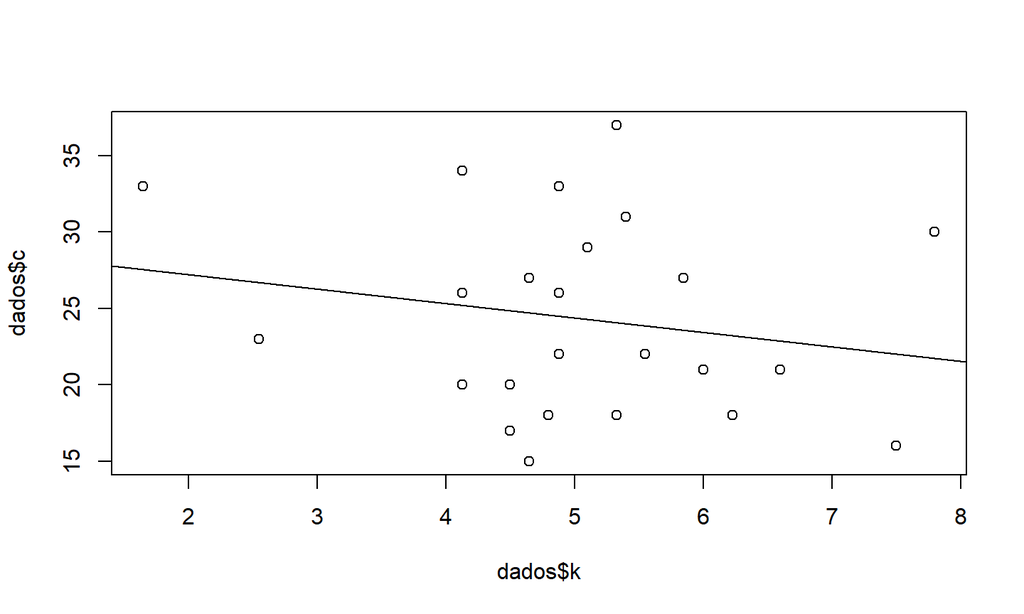

```r
library(ExpDes.pt) # carregar pacotes com dados de exemplo ("ex4")
dados <- ex4 # armazenar dados de exemplo em "dados"
plot(dados$k, dados$c) # gráfico de dispersão
abline(lm(dados$c~dados$k)) # tendência
```

## Exemplos no R - correlação

### \(2^\circ\) Checando normalidade dos dados

```r
shapiro.test(dados$k) # teste de normalidade para variável "k"
```

```
##
##  Shapiro-Wilk normality test
##
## data:  dados$k
## W = 0.94586, p-value = 0.22
```

```r
shapiro.test(dados$c) # teste de normalidade para variável "c"
```

```
##
##  Shapiro-Wilk normality test
##
## data:  dados$c
## W = 0.94823, p-value = 0.248
```

## Exemplos no R - correlação

### \(3^\circ\) Correlação

```r
cor(dados$k, dados$c, method = "pearson") # correlação de Pearson
```

```
## [1] -0.1985221
```

```r
cor(dados$k, dados$c, method = "spearman") # correlação de Spearman
```

```
## [1] -0.1026425
```

## Exemplos no R - matriz de correlação

```r
cor(dados[,c(4, 5, 6, 7,8)], method="spearman") # matriz de correlação
```

```
##             c            n           k            p          zn
## c   1.0000000  0.374891590 -0.10264250 -0.509996705 -0.58564272
## n   0.3748916  1.000000000  0.05101383 -0.009423871 -0.04378134
## k  -0.1026425  0.051013833  1.00000000  0.049627391 -0.08991710
## p  -0.5099967 -0.009423871  0.04962739  1.000000000  0.92410695
## zn -0.5856427 -0.043781337 -0.08991710  0.924106950  1.00000000
```

## Teste de correlação

Para calcular se a correlação entre duas variáveis é significativa ou não, pode-se usar:

\[ cor.test(x, y, method,...) \]

- **x** e **y** são os dois vetores com os dados a serem correlacionados.
- **method** define qual correlação deverá ser calculada:
  - Pearson: **method=“pearson”**
  - Spearman: **method=“spearman”**

## Exemplos no R - teste de correlação

```r
cor.test(dados$zn, dados$c, method = "spearman") # teste de spearman
```

```
##
##  Spearman's rank correlation rho
##
## data:  dados$zn and dados$c
## S = 3647, p-value = 0.002641
## alternative hypothesis: true rho is not equal to 0
## sample estimates:
##        rho
## -0.5856427
```

## Gráfico de correlação

O pacote **ggcorrplot** possui a função com mesmo nome e é a extensão do ggplot2 responsável por criar o gráfico de correlação:

```r
install.package("ggcorrplot")
```

\[ ggcorrplot(corr, lab, p.mat, type,...) \]

- **corr** é a matriz de correlação gerada pela função **cor()**.
- **lab** determina se deve (**=TRUE**) ou não (**=FALSE**) mostrar os valores da correlação.
- **p.mat** é o objeto com a matriz de p-valores de cada correlação criada com a função **cor_pmat()**.
  - Os p-valores não significativos (>0.05), são marcados com um “X”.
- **type** determina se deve mostrar apenas a parte superior (**=“upper”**) ou inferior (**=“lower”**) do gráfico.

## Exemplos no R - gráfico de correlação

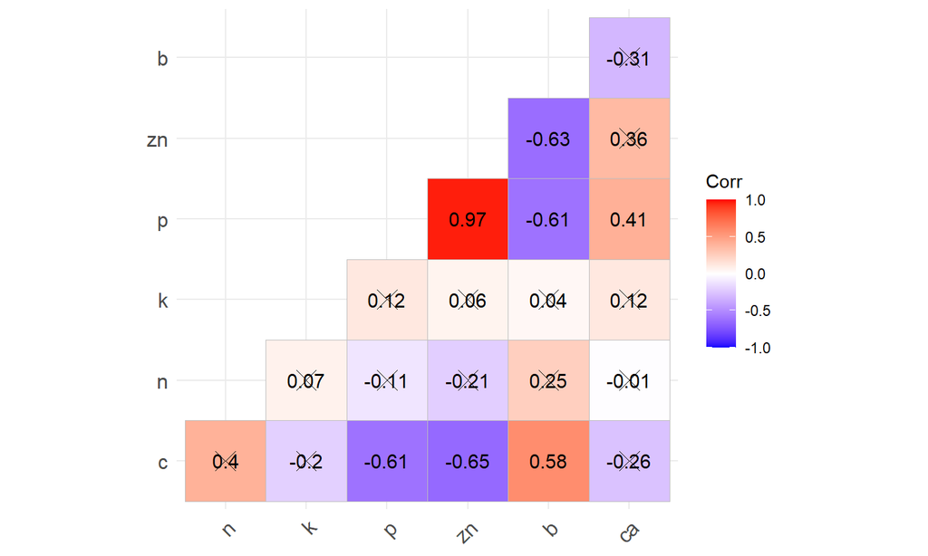

```r
library(ExpDes.pt) # carregando o pacote com dados de exemplo
dados <- ex4 # armazenando ex4 em "dados"
library(ggcorrplot) # carrgando pacote do gráfico de correlação
corr <- cor(dados[,c(4, 5, 6, 7, 8, 9, 10)]) # filtrando colunas
p.valores <- cor_pmat(dados[,c(4, 5, 6, 7, 8, 9, 10)]) # calculando p-valores
ggcorrplot(corr, lab=TRUE, p.mat=p.valores, type="lower") # grafico de correlacao
```

## Teste do chi-quadrado (\(\chi^2\))

Identificar a correlação entre duas variáveis númericas é, de certa forma, mais intuitivo. Basta observarmos o que ocorre com uma variável, quando outra variável aumenta ou diminui. Porém, como identificamos a correlação entre duas variáveis categóricas?

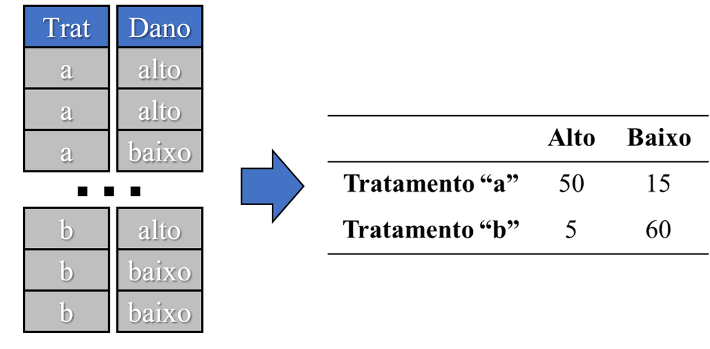

A solução é criar uma tabela de dupla entrada e verificar se a frequência entre os níveis de um fator, muda quando observamos os níveis de outro fator.

## Teste do chi-quadrado (\(\chi^2\))

A fórmula do teste de \(\chi^2\) é:

\[ \chi^2=\sum\frac{(o_i-e_i)^2}{e_i} \]

Onde \(o_i\) é o valor observado e \(e_i\) é o valor esperado, ou seja, a frequência que se espera, caso não exista associação entre as duas variávies.

\(*\) Quanto maior o valor, maior a probabilidade das variáveis estarem associadas, ou seja, menor será o seu p-valor referente na tabela da distribuição do \(\chi^2\).

## Teste do chi-quadrado (\(\chi^2\))

No R, o teste de correlação entre duas variáveis pode ser realizado pela função:

\[ chisq.test(x, y,...) \]

- **x** e **y** podem ser tanto um vetor com cada variável, quanto uma matriz ou objeto do tipo data frame.

## Exemplos no R - teste do chi-quadrado (\(\chi^2\))

```r
dados <- data.frame(dano=c(rep("alto", 55), rep("baixo", 75)),
                    trat=c(rep("a",50), rep("b", 5), rep("a", 15), rep("b", 60))) # dados fictícios
table(dados) # tabela de frequência
```

```
##        trat
## dano     a  b
##   alto  50  5
##   baixo 15 60
```

```r
chisq.test(dados$dano, dados$trat) # teste de chi-quadrado
```

```
##
##  Pearson's Chi-squared test with Yates' continuity correction
##
## data:  dados$dano and dados$trat
## X-squared = 61.013, df = 1, p-value = 5.669e-15
```

## Referências

- Bussab, W. O.; Morettin, P. A. **Estatística Básica (9 ed.)**. Saraiva, 2017, p. 553.
- Pimentel Gomes, F. **Curso de Estatística Experimental (12 ed.)**. Piracicaba, 1987, p. 467.
- Long, J.; Teetor, P. **R cookbook (2 ed.)**. O’Reilly, 2019.
  - https://rc2e.com/
- Crawley, M.J. **The R Book**. Willey, 2013, 975p.

## Códigos

```r
### Regressão linear
library(ExpDes.pt) # carregar pacotes com dados de exemplo ("ex1")
dados <- ex1 # armazenar dados de exemplo em "dados"
plot(dados$trat, dados$ig) # gráfico de dispersão
modelo.cubico <- lm(ig~trat+I(trat^2)+I(trat^3), data=dados) # modelo cúbico
par(mfrow=c(2,2)) # dividir painel gráfico
plot(modelo.cubico) # plotar gráfico
## Teste t (summary)
summary(modelo.cubico) # teste t
## Teste F (anova)
modelo.nulo <- lm(ig~1, data=dados) # modelo mais simples
modelo.linear <- lm(ig~trat, data=dados) # modelo linear
modelo.quadratico <- lm(ig~trat+I(trat^2), data=dados) # modelo quadrático
anova(modelo.nulo, modelo.linear, modelo.quadratico, modelo.cubico) # comparação dos modelos
anova(modelo.cubico) # anova da regressão
par(mfrow=c(2,2)) # dividir o painel
plot(modelo.linear) # plotar o modelo
## Teste da falta de ajuste
modelo.categorias <- lm(ig~as.factor(trat), data=dados) # modelo considerando categoria
anova(modelo.linear, modelo.categorias) # testar falta de ajuste
anova(modelo.categorias, modelo.quadratico) # comparar os modelos
par(mfrow=c(2,2)) # dividir o painel
plot(modelo.quadratico) # plotar o modelo
## pacote expdes
library(ExpDes.pt) # carregar pacote
dados <- ex1 # armazenar ex1 em "dados"
dic(dados$trat, dados$ig, quali=FALSE) # dic com fator quantitativo
## gráfico
library(ggplot2) # carregando o pacote
ggplot(dados) + # indicando os dados
  aes(x=trat, y=ig) + # distribuindo as variáveis
  geom_point() + # gráfico de dispersão
  geom_smooth(formula=y~poly(x, 2), method="lm") + # adicionando linha de regressão
  theme_classic() # alterando a estética


### Correlação
library(ExpDes.pt) # carregar pacotes com dados de exemplo ("ex4")
dados <- ex4 # armazenar dados de exemplo em "dados"
plot(dados$k, dados$c) # gráfico de dispersão
abline(lm(dados$c~dados$k)) # tendência
shapiro.test(dados$k) # teste de normalidade para variável "k"
shapiro.test(dados$c) # teste de normalidade para variável "c"
cor(dados$k, dados$c, method = "pearson") # correlação de Pearson
cor(dados$k, dados$c, method = "spearman") # correlação de Spearman
cor(dados[,c(4, 5, 6, 7,8)], method="spearman") # matriz de correlação
cor.test(dados$zn, dados$c, method = "spearman") # teste de spearman
install.package("ggcorrplot")
library(ExpDes.pt) # carregando o pacote com dados de exemplo
dados <- ex4 # armazenando ex4 em "dados"
library(ggcorrplot) # carrgando pacote do gráfico de correlação
corr <- cor(dados[,c(4, 5, 6, 7, 8, 9, 10)]) # filtrando colunas
p.valores <- cor_pmat(dados[,c(4, 5, 6, 7, 8, 9, 10)]) # calculando p-valores
ggcorrplot(corr, lab=TRUE, p.mat=p.valores, type="lower") # grafico de correlacao
dados <- data.frame(dano=c(rep("alto", 55), rep("baixo", 75)),
                    trat=c(rep("a",50), rep("b", 5), rep("a", 15), rep("b", 60))) # dados fictícios
table(dados) # tabela de frequência
chisq.test(dados$dano, dados$trat) # teste de chi-quadrado
```